# UNIT09D 案例：航空公司的市場區隔

中山大學管理學院第20組

2019-05-02 02:40:48

💡 學習重點：  
■ 集群分析的基本觀念  
■ 距離矩陣：Distance Matrix  
■ 層級式集群分析：Hierarchical Cluster Analysis  
■ 樹狀圖(Dendrogram)的判讀  
■ 依據樹狀圖決定要分多少群  
■ 以群組平均值檢視各族群的屬性

```r
pacman::p_load(dplyr, ggplot2)
```

### 【A】航空公司顧客資料集

```r
A = read.csv('data/AirlinesCluster.csv')
summary(A)
```

```
    Balance          QualMiles       BonusMiles       BonusTrans
 Min.   :      0   Min.   :    0   Min.   :     0   Min.   : 0.0
 1st Qu.:  18528   1st Qu.:    0   1st Qu.:  1250   1st Qu.: 3.0
 Median :  43097   Median :    0   Median :  7171   Median :12.0
 Mean   :  73601   Mean   :  144   Mean   : 17145   Mean   :11.6
 3rd Qu.:  92404   3rd Qu.:    0   3rd Qu.: 23800   3rd Qu.:17.0
 Max.   :1704838   Max.   :11148   Max.   :263685   Max.   :86.0
  FlightMiles     FlightTrans    DaysSinceEnroll
 Min.   :    0   Min.   : 0.00   Min.   :   2
 1st Qu.:    0   1st Qu.: 0.00   1st Qu.:2330
 Median :    0   Median : 0.00   Median :4096
 Mean   :  460   Mean   : 1.37   Mean   :4119
 3rd Qu.:  311   3rd Qu.: 1.00   3rd Qu.:5790
 Max.   :30817   Max.   :53.00   Max.   :8296
```

- Balance: 可用里程數
- QualMiles: 可用高等里程數
- BonusMiles: 過去12個月非飛行里程數
- BonusTrans: 過去12個月非飛行交易次數
- FlightMiles: 過去12個月飛行里程數
- FlightTrans: 過去12個月飛行交易次數
- DaysSinceEnroll: 會員年資 (天)

### 【B】資料常態化

🗿 為甚麼要做資料常態化？

```r
colMeans(A) %>% sort
```

```
    FlightTrans      BonusTrans       QualMiles     FlightMiles DaysSinceEnroll
         1.3736         11.6019        144.1145        460.0558       4118.5594
     BonusMiles         Balance
     17144.8462      73601.3276
```

```r
AN = scale(A) %>% data.frame
```

```r
sapply(AN, mean)
```

```
                 Balance                QualMiles               BonusMiles
 0.000000000000000027654  0.000000000000000026507 -0.000000000000000042736
              BonusTrans              FlightMiles              FlightTrans
-0.000000000000000071911  0.000000000000000014818  0.000000000000000010741
         DaysSinceEnroll
 0.000000000000000055637
```

```r
sapply(AN, sd)
```

```
        Balance       QualMiles      BonusMiles      BonusTrans     FlightMiles
              1               1               1               1               1
    FlightTrans DaysSinceEnroll
              1               1
```

### 【C】層級式集群分析 Hirarchical Clustering

1.距離矩陣

```r
d = dist(AN, method="euclidean")
```

2.層級式集群分析

```r
hc = hclust(d, method='ward.D')
```

3.畫出樹狀圖

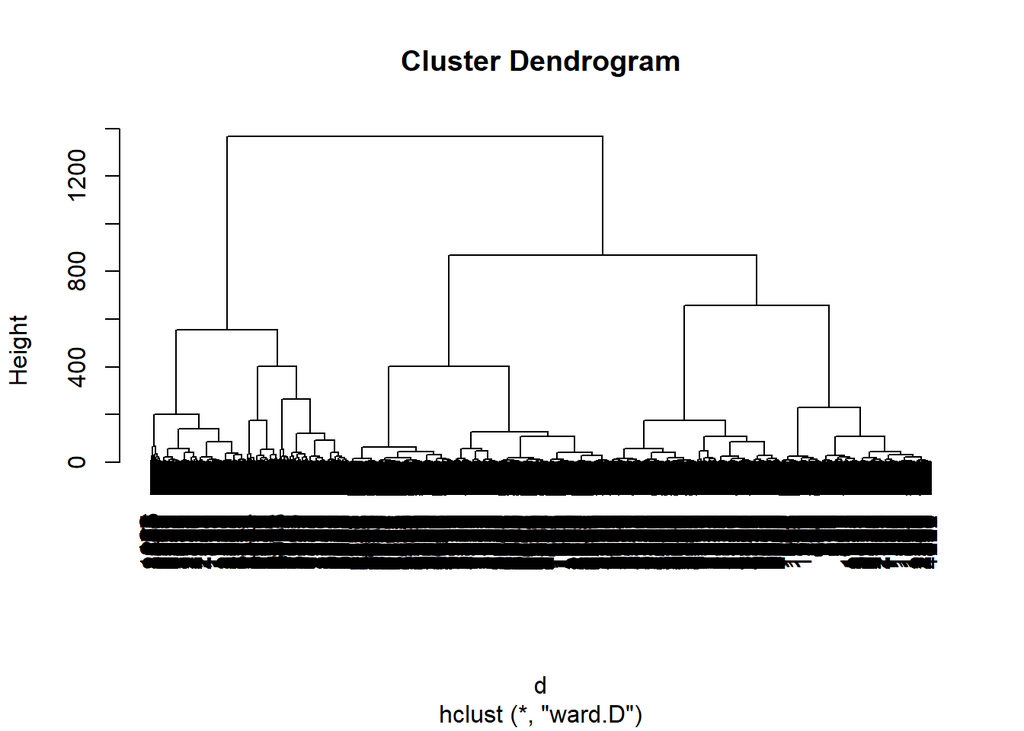

```r
plot(hc)
```

🗿 如何從樹狀圖決定群數？

4.分割群組

```r
kg = cutree(hc, k=5)
table(kg)
```

```
kg
   1    2    3    4    5
 776  519  494  868 1342
```

### 【D】觀察群組特性

```r
sapply(split(A,kg), colMeans) %>% round(2)
```

```
                       1         2         3        4        5
Balance         57866.90 110669.27 198191.57 52335.91 36255.91
QualMiles           0.64   1065.98     30.35     4.85     2.51
BonusMiles      10360.12  22881.76  55795.86 20788.77  2264.79
BonusTrans         10.82     18.23     19.66    17.09     2.97
FlightMiles        83.18   2613.42    327.68   111.57   119.32
FlightTrans         0.30      7.40      1.07     0.34     0.44
DaysSinceEnroll  6235.36   4402.41   5615.71  2840.82  3060.08
```

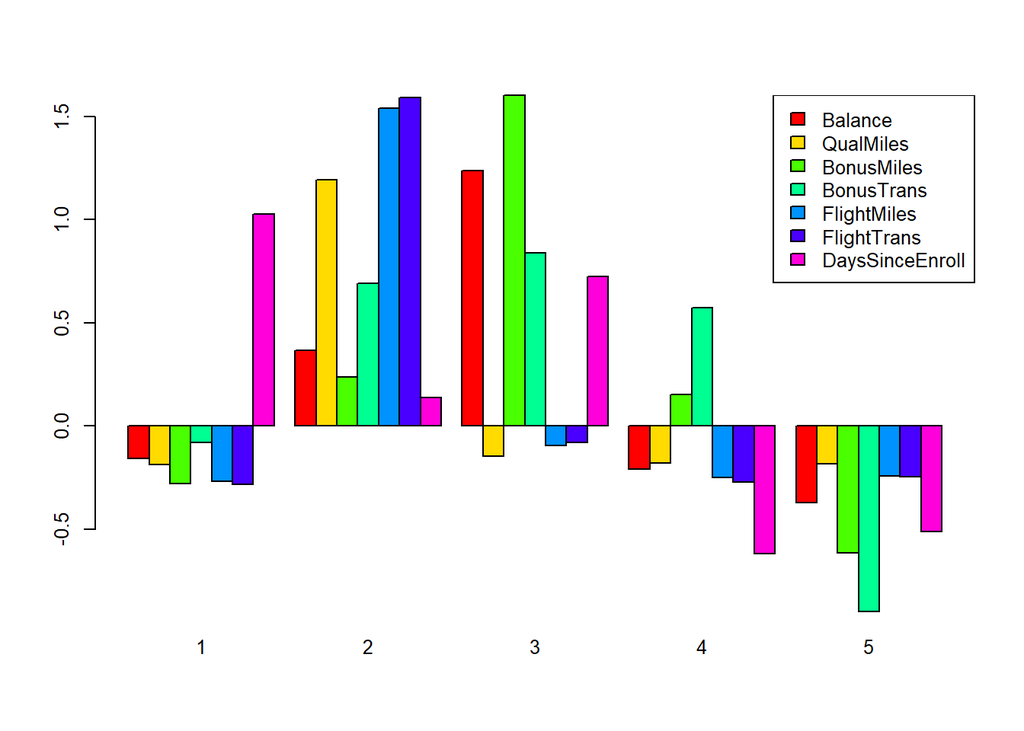

```r
par(cex=0.8)
split(AN,kg) %>% sapply(colMeans) %>% barplot(beside=T,col=rainbow(7))
legend('topright',legend=colnames(A),fill=rainbow(7))
```

💡 ■ 請你們為這五個族群各設計一個行銷策略：  
1.針對該群客戶,提供里程數加倍的優惠,鼓勵他們繼續使用該航空接駁,並提供發言平台,供老顧客們發言暢談  
2.高需求性,有可能為商務客,出差的機率大,可以使用機加酒服務  
3.住在較偏遠的地方,單趟車資較高,可以使用哩程數折抵,減少他們的因高車資而抗拒的服務  
4.提供專人24hr司機服務,到府接送  
5.廣告投放的首要客群,提供較於其他企業不一樣的服務

💡 ■ 統計上最好的分群也是實務上最好的分群嗎?  
不一定，在商業考量上，以最小成本達到最大效益才是最佳的策略，因此統計上分群的數量，針對不同問題情境，也會有不同最佳群數，呈現最貼近真實的消費者樣貌。

💡 ■ 除了考慮群間和群間距離之外，實務上的分群通常還需要考慮那些因數？  
根據不同商業目的，所關心的目標/變數也將不同，因此應分析該商業情境的核心問題，嘗試找出影響問題結果的相關變數，並以相關性最高者作為觀察標準，才能更貼近獲得最佳解的消費者樣貌。  
以本航空公司為例，為描繪更加準確的消費者輪廓，共使用7項變數作為觀察：觀察會員年資、可用里程數與高等里程數、是/非飛行里程數、是/非飛行交易次數。若關心的焦點改為：如何喚起沉睡客戶時，則應先找到其沉睡原因，相關變數可增加如：工作類別、娛樂型態等，判斷其經濟能力是否能負擔機票支出、工作環境是否需使用飛航系統作為移動工具、其娛樂休閒型態是否有使用到飛航服務之可能性，以作為制定分眾喚起策略之依據。